# Pakiet ggplot2 - mapy

poskRamiacze danych

sezon 3 / odcinek 4  
Naciśnij `A` by zamienić slajdy na ciągły tekst.  
Naciśnij `T` by wyświetlić spis treści.

## O czym to będzie

W tym odcinku nauczymy się

- Jak wczytywać dane o mapach
- Jak przedstawiać na mapach informacje za pomocą koloru wypełnienia
- Jak przedstawiać na mapach informacje za pomocą wielkości punktów lub słupków

W tym odcinku będziemy pracować ze zbiorem danych `mandatySejmik2014`.

## Zbiór danych

W tym odcinku będziemy pracować na zbiorze danych o wynikach wyborów samorządowych z roku 2014 do sejmików.

```r
library(SmarterPoland)
head(mandatySejmik2014)
```

```
##          Wojewodztwo PSL PiS PO SLD Inne ProcentWaznychGlosow     long
## 1       Dolnoslaskie   5   9 16   2    4             36.83847 16.38088
## 2 Kujawsko-Pomorskie  10   7 14   2    0             36.60884 18.50218
## 3            Lodzkie  10  12 10   1    0             40.13651 19.40827
## 4          Lubelskie  12  13  7   1    0             41.98316 22.90889
## 5           Lubuskie   8   5 10   5    2             36.75825 15.34234
## 6        Malopolskie   8  17 14   0    0             40.56634 20.30085
##        lat
## 1 51.07988
## 2 53.02223
## 3 51.55958
## 4 51.24725
## 5 52.20549
## 6 49.84203
```

# Pliki z mapami - shape files

Aby przedstawiać informacje na mapach w programie R, należy wpierw wczytać obrysy map. Te obrysy są udostępnione w plikach o rozszerzeniu `.shp`, nazywanych *shape files*.

Pliki, które wykorzystam tutaj pochodzą z bazy danych GADM http://www.gadm.org i mają pewne niewielkie błędy w kodowaniu, które ręcznie naprawimy. W katalogu `dane/POL_adm` znajdują się kształty obszarów na różnych poziomach szczegółowości. Plik `POL_adm0.shp` to obrys całego kraju, `POL_adm1.shp` to obrysy województw a `POL_adm2.shp` to obrysy gmin. Funkcją `readShapePoly()` wczytamy dane o obrysach województw do zmiennej `shp1`. Zmienna `shp1@data$VARNAME_1` zawiera nazwy województw, musimy w nich poprawić nazwę dla województwa Łódzkiego.

```r
library(maptools)
library(rgdal)
library(gpclib)
gpclibPermit()
```

```
## [1] TRUE
```

```r
shp1 <- readShapePoly("../dane/POL_adm/POL_adm1.shp")

# W zmiennej VARNAME_1 znajdują się nazwy województw
shp1@data$VARNAME_1 <- as.character(shp1@data$VARNAME_1)
shp1@data$VARNAME_1
```

```
##  [1] "Wielkopolskie"       "Kujawsko-Pomorskie"  "Malopolskie"
##  [4] "L\xf3dzkie"          "Dolnoslaskie"        "Lubelskie"
##  [7] "Lubuskie"            "Mazowieckie"         "Opolskie"
## [10] "Podlaskie"           "Pomorskie"           "Slaskie"
## [13] "Podkarpackie"        "Swietokrzyskie"      "Warminsko-Mazurskie"
## [16] "Zachodniopomorskie"
```

```r
# poprawiamy kodowanie polskich znaków
shp1@data$VARNAME_1[4] <- "Lodzkie"
```

# Rysowanie mapy

Aby dane wczytane przez funkcję `readShapePoly()` można było narysować w pakiecie `ggplot2` należy je najpierw przekonwertować funkcją `fortify()`. Zmienia ona format danych na tabelaryczny, w poniższym przykładzie nowy format dla obrysów województw jest zapisany w zmiennej `shp1f`.

Pierwsze dwie kolumny tej tabeli to współrzędne geograficzne punktów na obrysie każdego województwa. Używając geometrii `geom_path` narysujemy te obrysy.

```r
library(ggplot2)
# fortify zmienia format danych na zgodny z pakietem ggplot2
shp1f <- fortify(shp1, region = "VARNAME_1")
head(shp1f, 4)
```

```
##       long      lat order  hole piece          group           id
## 1 16.16883 51.66089     1 FALSE     1 Dolnoslaskie.1 Dolnoslaskie
## 2 16.19236 51.65255     2 FALSE     1 Dolnoslaskie.1 Dolnoslaskie
## 3 16.22376 51.65711     3 FALSE     1 Dolnoslaskie.1 Dolnoslaskie
## 4 16.24667 51.66169     4 FALSE     1 Dolnoslaskie.1 Dolnoslaskie
```

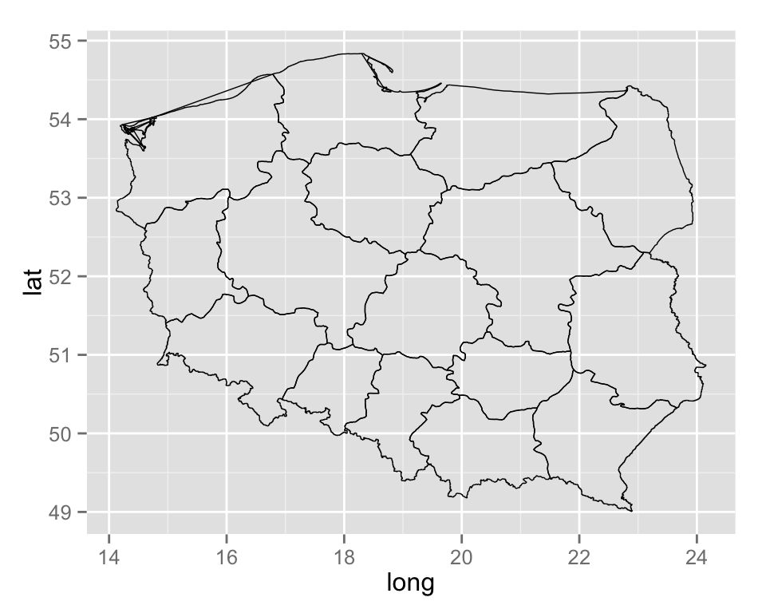

```r
ggplot() +
  geom_path(data=shp1f, aes(x=long, y=lat, group=id), colour="black", size=0.25)
```

# Rysowanie mapy

Geometrii `geom_path()` będziemy używać do rysowania obrysów województw. Do zaznaczania wartości liczbowych za pomocą koloru wypełnienia użyjemy geometrii `geom_map()`. Argument `map=` tej geometrii wskazuje obiekt przedstawiający województwa, argument `data=` wskazuje na obiekt z danymi liczbowymi. W mapowaniach określamy cechę `map_id=` aby wskazać nazwy województw a `fill=` by wskazać która zmienna ma być przedstawiona kolorem wypełnienia.

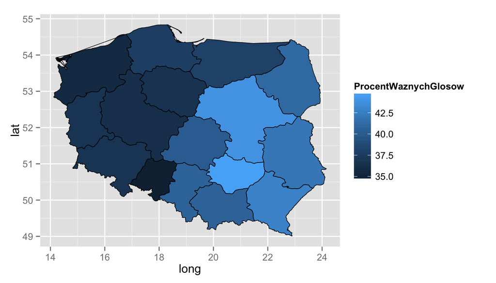

```r
ggplot() +
    geom_map(data=mandatySejmik2014, aes(map_id=Wojewodztwo, fill=ProcentWaznychGlosow),
             map=shp1f) +
    geom_path(data=shp1f, aes(x=long, y=lat, group=id), colour="black", size=0.25)
```

# Rysowanie mapy

Mapy można rysować w różnych projekcjach. Aby je wybrać wystarczy dodać wywołanie funkcji `coord_map()`. Poniżej dwa przykładowe projekcie. Listę projekcji z opisem właściwości znaleźć można pod adresem http://en.wikipedia.org/wiki/List_of_map_projections

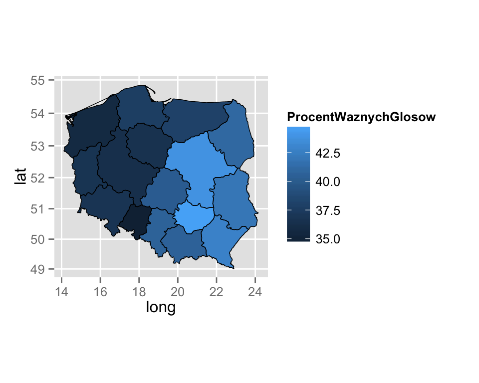

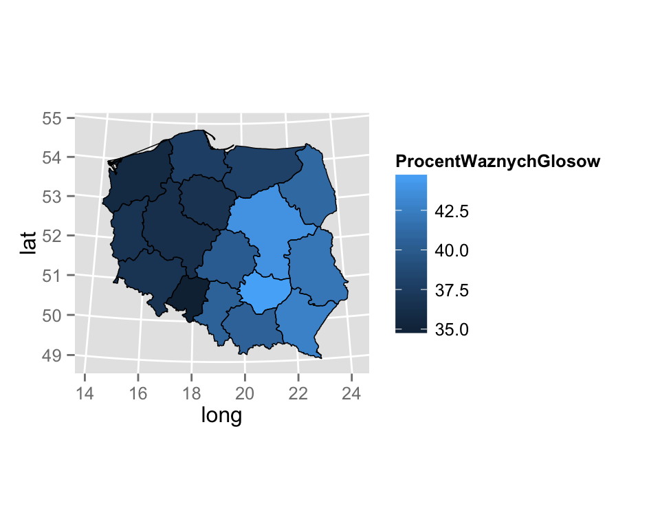

```r
mapka <- ggplot() +
    geom_map(data=mandatySejmik2014, aes(map_id=Wojewodztwo, fill=ProcentWaznychGlosow),
             map=shp1f) +
    geom_path(data=shp1f, aes(x=long, y=lat, group=id), colour="black", size=0.25)

mapka + coord_map(projection="mercator")
mapka + coord_map(projection="stereographic")
```

# Rysowanie mapy - zmienna jako kolor wypełnienia

Mapy modyfikuje się podobnie jak inne wykresy w pakiecie `ggplot2`. Przedstawmy kilka przykładowych zmian, funkcją `theme_bw()` zmieniamy domyślny motyw wykresu, funkcją `scale_fill_gradient()` zmieniamy sposób reprezentacji zmiennej za pomocą koloru wypełniania, a dodatkowymi argumentami funkcji `theme()` usuwamy wszystkie dodatkowe elementy wykresu.

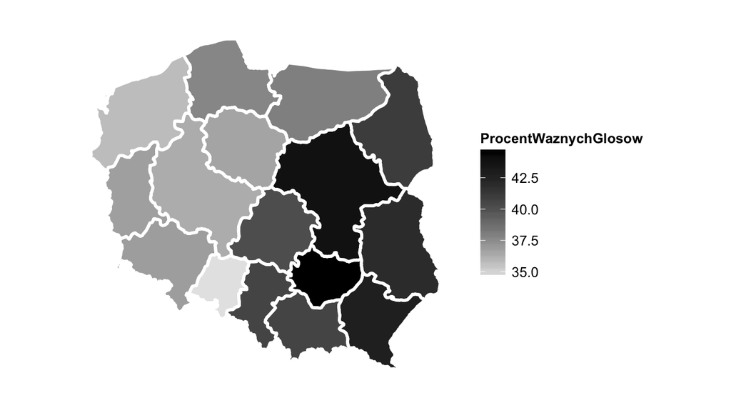

```r
ggplot() +
    geom_map(data=mandatySejmik2014, aes(map_id=Wojewodztwo, fill=ProcentWaznychGlosow),
             map=shp1f) +
    geom_path(data=shp1f, aes(x=long, y=lat, group=id), colour="white", size=1) +
  coord_map(projection="mercator") +
  theme_bw() +
  scale_fill_gradient(low = "grey90", high = "black") +
  theme(axis.ticks = element_blank(),     panel.border = element_blank(),
        axis.text.x = element_blank(),    axis.text.y = element_blank(),
        panel.grid.minor=element_blank(), panel.grid.major=element_blank(),
        axis.title.x = element_blank(),   axis.title.y = element_blank())
```

# Rysowanie mapy - zmienna jako wielkość punktu.

Alternatywny sposób prezentacji informacji na mapie jest wielkość punktu. Do rysowania punktów można wykorzystać geometrię `geom_point()`, wskazując jako współrzędne punktu środki województw a wielkość punktu uzależniamy od zmiennej `ProcentWaznychGlosow`. Aby punkty były bardziej widoczne powiększamy je modyfikując mapowanie za pomocą funkcji `scale_size_continuous()`.

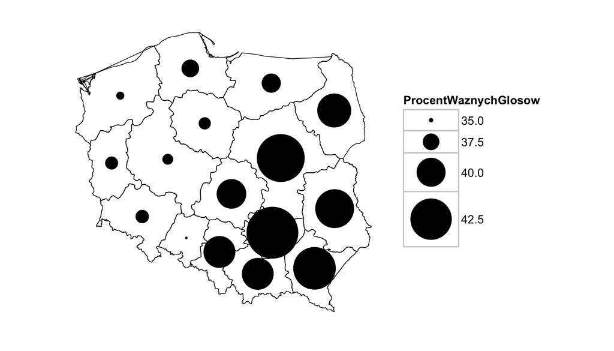

```r
ggplot() +
  geom_point(data=mandatySejmik2014, aes(x=long, y=lat, size=ProcentWaznychGlosow)) +
  geom_path(data=shp1f, aes(x=long, y=lat, group=id), colour="black", size=0.25) +
  coord_map(projection="mercator") +
  theme_bw() +
  scale_size_continuous(range=c(1,20)) +
  theme(axis.ticks = element_blank(),     panel.border = element_blank(),
        axis.text.x = element_blank(),    axis.text.y = element_blank(),
        panel.grid.minor=element_blank(), panel.grid.major=element_blank(),
        axis.title.x = element_blank(),   axis.title.y = element_blank())
```

# Rysowanie mapy - zmienna jako długość paska

Jeszcze innym sposobem prezentacji danych liczbowych na mapach są długości słupków. Aby dorysować informację o mandatach zdobytych przez PO wykorzystamy geometrię `geom_rect()`. Należy do niej podać współrzędne `xmin` i `xmax` oznaczające początek i koniec słupka oraz `ymin` i `ymax` zależne od wartości zmiennej `PO`.

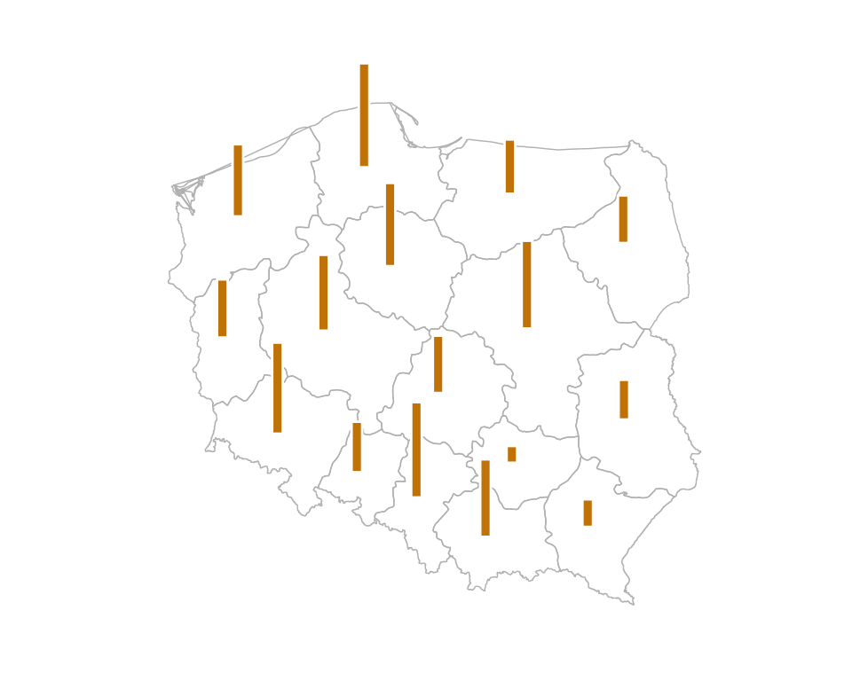

```r
ggplot() +
  geom_path(data=shp1f, aes(x=long, y=lat, group=id), colour="grey", size=0.25) +
  geom_rect(data=mandatySejmik2014, aes(xmin=long-0.3, xmax=long-0.1,
                                        ymin=lat, ymax=lat + PO/15), fill="orange3", color="white") +
  coord_map(projection="mercator") +
  theme_bw() +
  scale_size_continuous(range=c(1,20)) +
  theme(axis.ticks = element_blank(),     panel.border = element_blank(),
        axis.text.x = element_blank(),    axis.text.y = element_blank(),
        panel.grid.minor=element_blank(), panel.grid.major=element_blank(),
        axis.title.x = element_blank(),   axis.title.y = element_blank())
```

# Rysowanie mapy - zmienna jako długość paska

Na poniższym wykresie rozszerzamy pomysł z poprzedniego slajdu, dodając również słupki prezentujące liczbę zdobytych mandatów przez PiS, PSL i SLD.

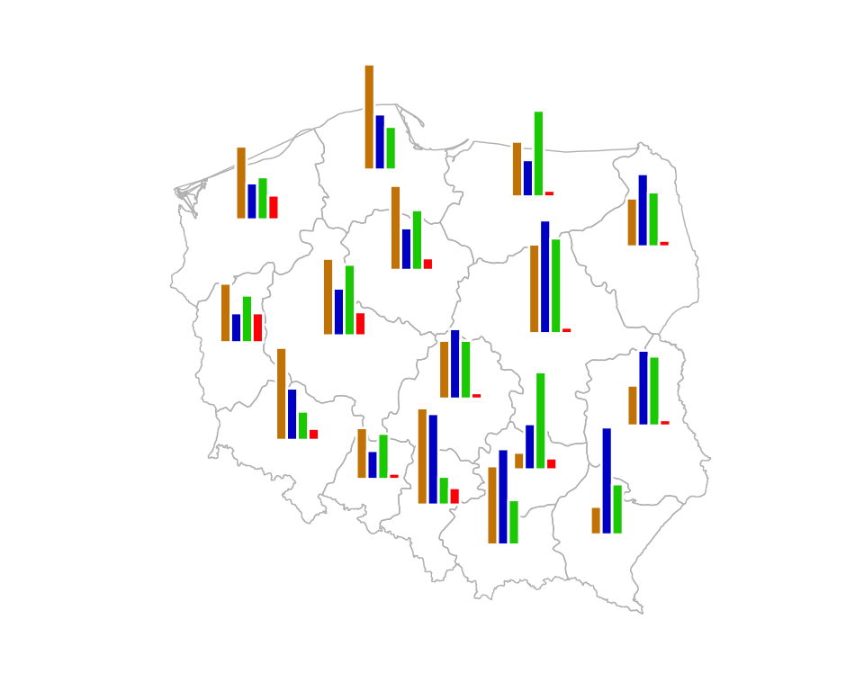

```r
ggplot() +
  geom_path(data=shp1f, aes(x=long, y=lat, group=id), colour="grey", size=0.25) +
  geom_rect(data=mandatySejmik2014, aes(xmin=long-0.3, xmax=long-0.1,
                                        ymin=lat, ymax=lat + PO/15), fill="orange3", color="white") +
  geom_rect(data=mandatySejmik2014, aes(xmin=long-0.1, xmax=long+0.1,
                                        ymin=lat, ymax=lat + PiS/15), fill="blue3", color="white") +
  geom_rect(data=mandatySejmik2014, aes(xmin=long+0.1, xmax=long+0.3,
                                        ymin=lat, ymax=lat + PSL/15), fill="green3", color="white") +
  geom_rect(data=mandatySejmik2014, aes(xmin=long+0.5, xmax=long+0.3,
                                        ymin=lat, ymax=lat + SLD/15), fill="red", color="white") +
  coord_map(projection="mercator") +
  theme_bw() +
  scale_size_continuous(range=c(1,20)) +
  theme(axis.ticks = element_blank(),     panel.border = element_blank(),
        axis.text.x = element_blank(),    axis.text.y = element_blank(),
        panel.grid.minor=element_blank(), panel.grid.major=element_blank(),
        axis.title.x = element_blank(),   axis.title.y = element_blank())
```

# Co dalej

- Więcej informacji o tym jak budować wykresy w pakiecie ggplot2 znaleźć można w rozdziale 4 książki *,,Przewodnik po pakiecie R’’*. Więcej informacji o tej książce http://www.biecek.pl/R/
- Wiele przydatnych wskazówek można również znaleźć w internetowej książce *,,Cookbook for R’’* http://www.cookbook-r.com/Graphs/
- Bardzo rozbudowana dokumentacja dla pakietu ggplot2 dostępna jest na stronie *,,ggplot2’’* http://docs.ggplot2.org/current/index.html